# Rolling average salinity

Chelsey Wegener

10/19/2020

Cleaning up environmental salinity data: Using rolling 30 day average to remove data points that are +/- 2 standard deviations away from mean.

*Notes:*  
-Accessed and downloaded all data on September 30, 2020.

-I downloaded all data available from 1/1/2017-12/31/2019. None of the following data sources had air temperature so I’ll look into additional data sources for that.

-China camp http://cdmo.baruch.sc.edu/aqs/zips.cfm Data logged every 15 minutes. Requested citation format: NOAA National Estuarine Research Reserve System (NERRS). System-wide Monitoring Program. Data accessed from the NOAA NERRS Centralized Data Management Office website: http://cdmo.baruch.sc.edu/; accessed 30 September 2020.

-Richardson Bay/NERR data. Data logged every 15 minutes.Data from Matt Ferner and Anna Deck.

-EOS https://oceanview.pfeg.noaa.gov/erddap/tabledap/rtcctdRTCysi.html. This is the archived data. There is also data at https://oceanview.pfeg.noaa.gov/erddap/tabledap/rtcctdRTCysi.html but I did not use this. Data logged every 6 minutes. time in UTC.

-Point Fort http://erddap.cencoos.org/erddap/tabledap/fort-point.html?time%2Csea_water_temperature%2Csea_water_temperature_qc_agg%2Cz&time%3E%3D2020-09-20T21%3A07%3A41Z&time%3C%3D2020-09-29T12%3A00%3A00Z. time in UTC. Data logged every 6 minutes.

*EOS pier/Tiburon*

Clear environment, load packages, read in data. I think there are packages here that I don’t use for this. This is a running list of packages I’m using in my thesis work.

```r
rm(list=ls())

library(tidyverse)
```

```r
library(ggpubr)
library(scales)
library(chron)
library(plotly)
library(taRifx)
library(aweek)
library(easypackages)
library(renv)
library(here)
library(ggthemes)
library(gridExtra)
library(patchwork)
library(tidyquant)
library(recipes)
library(cranlogs)
library(knitr)

eos<-read.csv("C:/Users/chels/Box Sync/Thesis/Data/Working data/Bouy data/eos_bouy_r.csv", header = TRUE, sep=",", fileEncoding="UTF-8-BOM", stringsAsFactors = FALSE)
```

Convert to date column to date. After as.Date you’re indicating which column you’re changing and the format that it’s in.

```r
eos$date<-as.Date(eos$date, format = c("%m/%d/%Y"))
```

Plot raw data

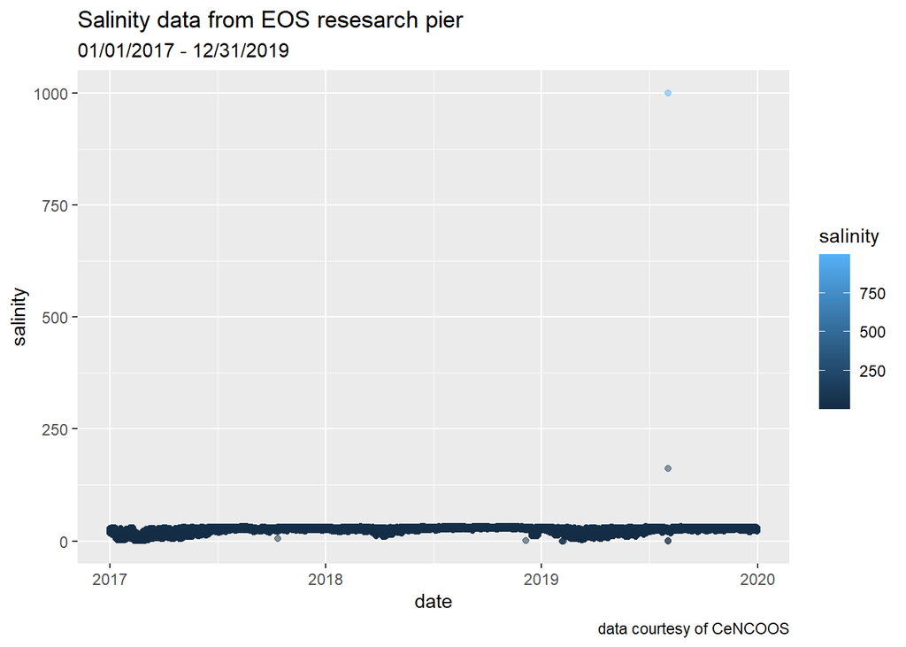

```r
eos%>%
  ggplot(aes(x=date, y=salinity, color=salinity))+
  geom_point(alpha=0.5)+
  labs(title="Salinity data from EOS resesarch pier",
       subtitle="01/01/2017 - 12/31/2019",
       caption= "data courtesy of CeNCOOS")
```

Make a custon function to calculate mean, sd, 95% confidence interval where x is a numeric vector. Here “hi” and “lo” are defined as 2 strandard deviations away from mean. This creates a functin so you don’t need to change anything here/this step does not manipulate the data. You can change the equation to define the hi and low as 3 or however many sds away you would like. na.rm=TRUE removes any “NA” values. “ret” are the new columns it’ll add when you run this on a df.

```r
custom_stat_fun_2<-function(x, na.rm=TRUE){
  m<-mean(x, na.rm=TRUE)
  s<- sd(x, na.rm=TRUE)
  hi<-m+2*s
  lo<-m-2*s
  ret<-c(mean=m, stdev=s, hi.95=hi, lo.95=lo)
}
```

Roll apply using custom stat function. Monthly rolling average, weekly didn’t get rid of all outliers. Width will depend on the frequencey of the time series. Data collected every 6 minutes so width=1680 is 7 days, 3360 is 14 days, 7200 is 30 days. 240 observations per day. select = what paramter do you want to apply the rolling average to, in this case we’re interested in salinity. FUN= is the fuction we just created.

When I do 7 day and 14 day rolling average, a clear outlier remains. 30 days seems to be the best approach. In my origonal data dive of all the raw environmental data (https://cmwegener.github.io/thesis/bouy_data_dive.png) salinity at eos seemed to have the most extreme outliers. I want to remove outliers the same way for all my enviornmental data so I figured if this method works here, it should work for all the other ones.

```r
s_data_rollstats<-eos%>%
  tq_mutate(
    select= salinity,
    mutate_fun= rollapply,
    width= 7200,
    align= "right",
    by.column= FALSE,
    FUN= custom_stat_fun_2,
    na.rm= TRUE)
```

Look at the new df in the environment and sort hi and lo columns (or just graph it). Looks like it worked. Let’s filter and graph.

For filtering I’m selecting to keep values that are inbetween “hi.95” and “lo.95” that we calculted using our custom funtion.

NOTE: since I’m doing a 30 day rolling average, the first 30 days (or 7200 observations) will be “NA”.

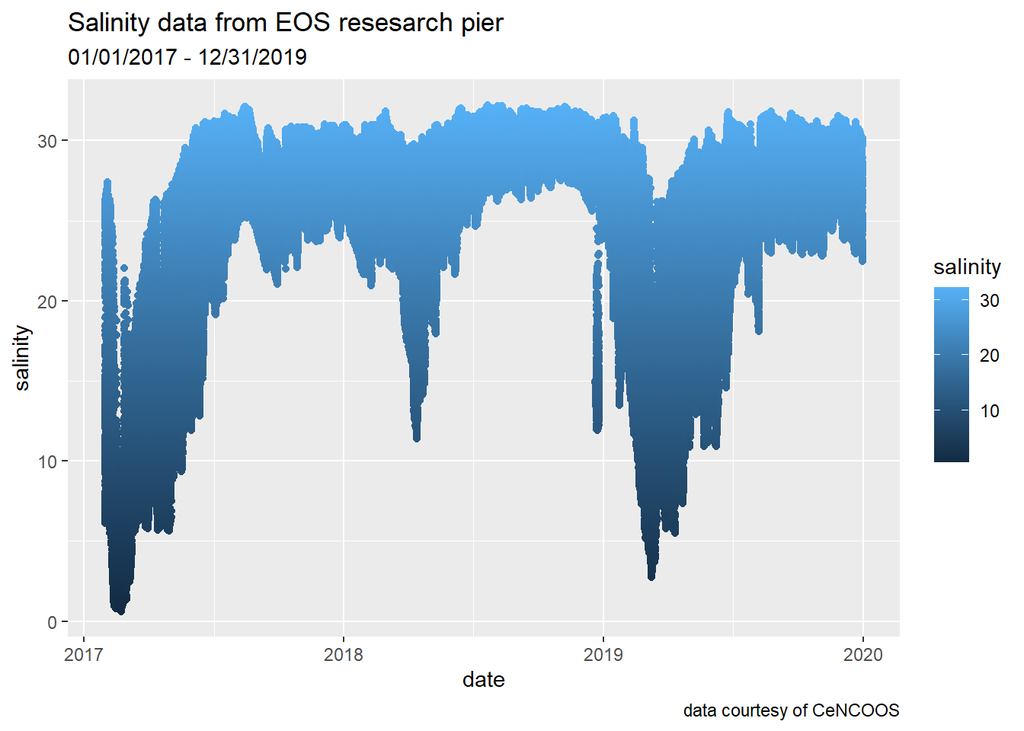

```r
clean_data<-filter(s_data_rollstats, salinity <hi.95 & salinity >lo.95)

eos_graph<- ggplot(data = clean_data, mapping = aes(x = date, y = salinity, color=salinity)) + geom_point()+
  labs(title="Salinity data from EOS resesarch pier",
       subtitle="01/01/2017 - 12/31/2019",
       caption= "data courtesy of CeNCOOS")

ggplot(data = clean_data, mapping = aes(x = date, y = salinity, color=salinity)) + geom_point()+
  labs(title="Salinity data from EOS resesarch pier",
       subtitle="01/01/2017 - 12/31/2019",
       caption= "data courtesy of CeNCOOS")
```

*Richardson Bay*

Clear environment except for what we need (optional, I like to keep my envrionment tidy since these are large datasets). We need to keep “eos_graph” and the function we made “custom_stat_fun_2”. Read in data.

```r
rm(list=ls()[! ls() %in% c("eos_graph","custom_stat_fun_2")])

rb<-read.csv("C:/Users/chels/Box Sync/Thesis/Data/Working data/Bouy data/richardson_bay_all.csv", header = TRUE, sep=",", fileEncoding="UTF-8-BOM", stringsAsFactors = FALSE)
```

Convert to date. I decided to make this a new column. Note that the format is different than the eos df so we have to change that here. (ex. %y=yy vs %Y=yyy, 17 vs 2017)

```r
rb$date<-as.Date(rb$DateTimeStamp, format = c("%m/%d/%y"))
```

Plot raw data

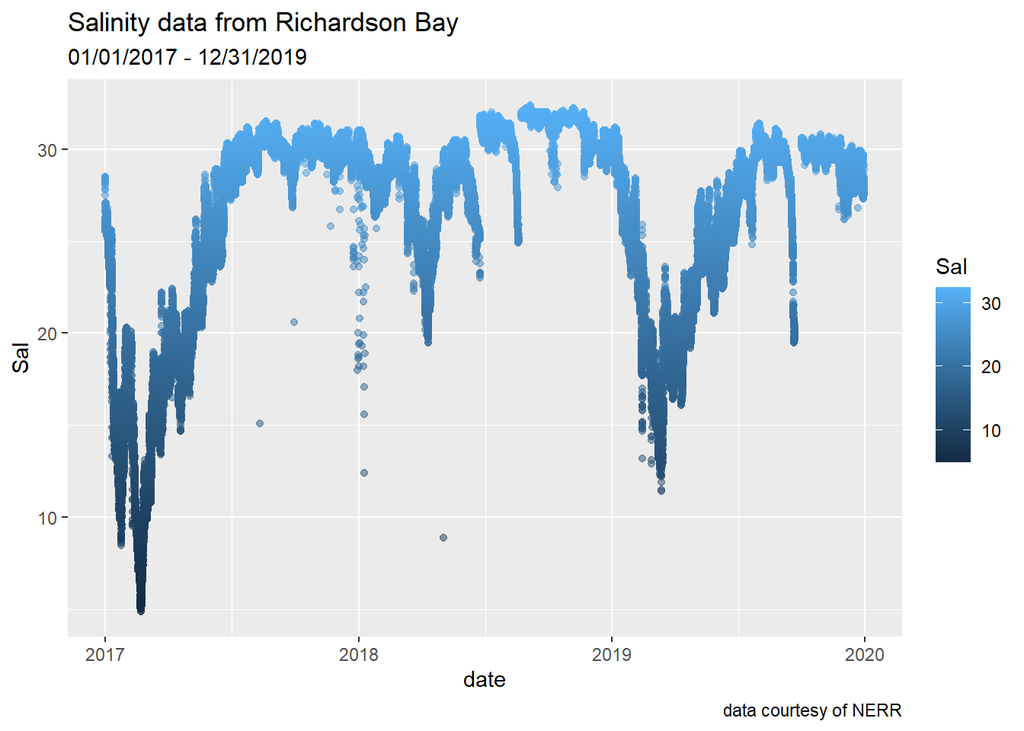

```r
rb%>%
  ggplot(aes(x=date, y=Sal, color=Sal))+
  geom_point(alpha=0.5)+
  labs(title="Salinity data from Richardson Bay",
       subtitle="01/01/2017 - 12/31/2019",
       caption= "data courtesy of NERR")
```

Roll apply using custom stat function. Again, width will depend on the frequencey of the time series. Data collected every 15 min so width = 672 is 7 days, 1344 is 14 days, 2880 is 30 days. 96 observations per day. Since 30 days worked for eos data I’m going to the same here so that it’s constent.

```r
s_data_rollstats<-rb%>%
  tq_mutate(
    select= Sal,
    mutate_fun= rollapply,
    width= 2880,
    align= "right",
    by.column= FALSE,
    FUN= custom_stat_fun_2,
    na.rm= TRUE)
```

Looks like it worked. Let’s filter and graph

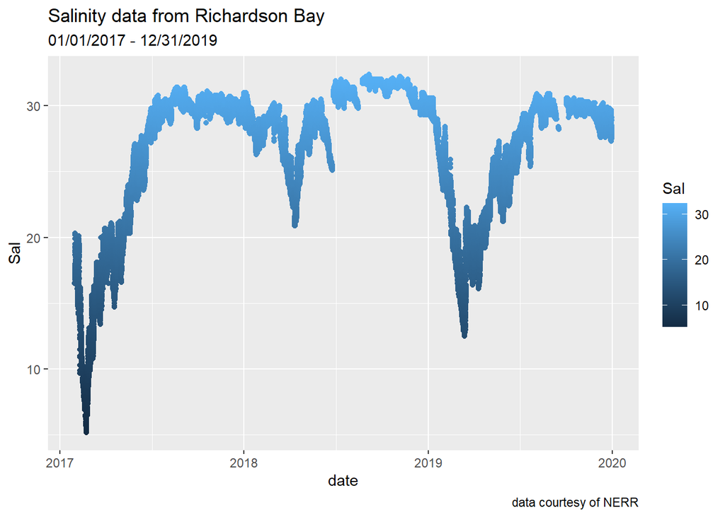

```r
clean_data<-filter(s_data_rollstats, Sal <hi.95 & Sal >lo.95)

rb_graph<- ggplot(data = clean_data, mapping = aes(x = date, y = Sal, color=Sal)) + geom_point()+
  labs(title="Salinity data from Richardson Bay",
       subtitle="01/01/2017 - 12/31/2019",
       caption= "data courtesy of NERR")

ggplot(data = clean_data, mapping = aes(x = date, y = Sal, color=Sal)) + geom_point()+
  labs(title="Salinity data from Richardson Bay",
       subtitle="01/01/2017 - 12/31/2019",
       caption= "data courtesy of NERR")
```

*China Camp*

Clear environment. We need to keep “eos_graph”, “rb_graph”, and “custom_stat_fun_2”. Read in data.

```r
rm(list=ls()[! ls() %in% c("eos_graph","custom_stat_fun_2", "rb_graph")])

cc<-read.csv("C:/Users/chels/Box Sync/Thesis/Data/Working data/Bouy data/china_camp_all.csv", header = TRUE, sep=",", fileEncoding="UTF-8-BOM", stringsAsFactors = FALSE)
```

Convert to date column to date.

```r
cc$date<-as.Date(cc$DateTimeStamp, format = c("%m/%d/%Y"))
```

Plot raw data

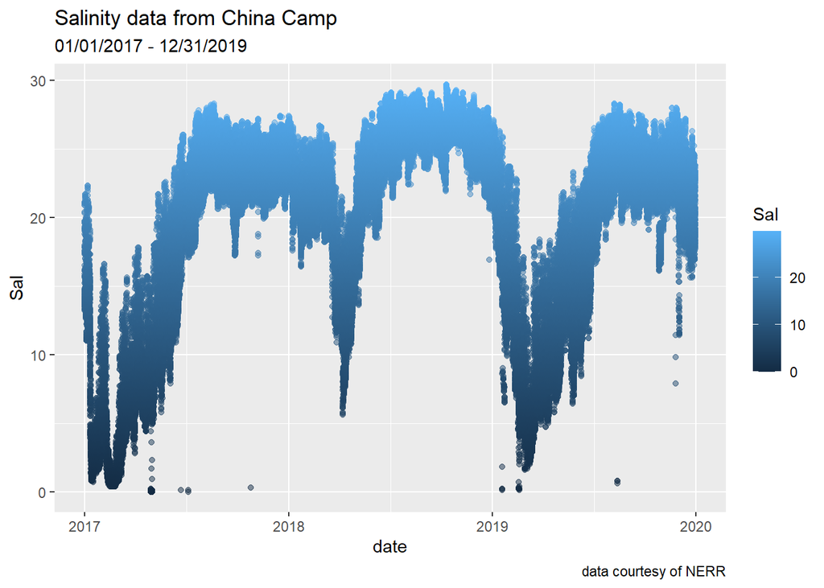

```r
cc%>%
  ggplot(aes(x=date, y=Sal, color=Sal))+
  geom_point(alpha=0.5)+
  labs(title="Salinity data from China Camp",
       subtitle="01/01/2017 - 12/31/2019",
       caption= "data courtesy of NERR")
```

Roll apply using custom stat function. Again, width will depend on the frequencey of the time series. Data collected every 15 min so width = 672 is 7 days, 1344 is 14 days, 2880 is 30 days. 96 observations per day. Since 30 days worked for eos data I’m going to the same here so that it’s constent.

```r
s_data_rollstats<-cc%>%
  tq_mutate(
    select= Sal,
    mutate_fun= rollapply,
    width= 2880,
    align= "right",
    by.column= FALSE,
    FUN= custom_stat_fun_2,
    na.rm= TRUE)
```

Looks like it worked. Let’s filter and graph

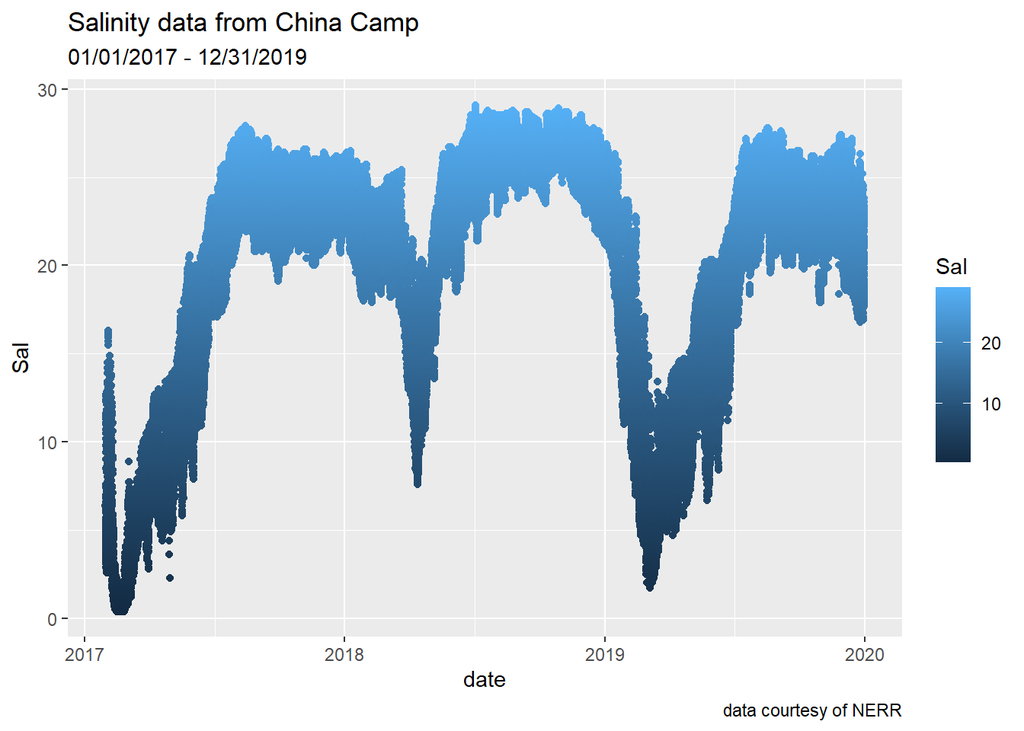

```r
clean_data<-filter(s_data_rollstats, Sal <hi.95 & Sal >lo.95)

cc_graph<- ggplot(data = clean_data, mapping = aes(x = date, y = Sal, color=Sal)) + geom_point()+
  labs(title="Salinity data from China Camp",
       subtitle="01/01/2017 - 12/31/2019",
       caption= "data courtesy of NERR")

ggplot(data = clean_data, mapping = aes(x = date, y = Sal, color=Sal)) + geom_point()+
  labs(title="Salinity data from China Camp",
       subtitle="01/01/2017 - 12/31/2019",
       caption= "data courtesy of NERR")
```

*Fort Point*

Clear environment. We need to keep “eos_graph”, “rb_graph”, “cc_graph” and “custom_stat_fun_2”. Read in data.

```r
rm(list=ls()[! ls() %in% c("eos_graph","custom_stat_fun_2", "rb_graph","cc_graph")])

fp<-read.csv("C:/Users/chels/Box Sync/Thesis/Data/Working data/Bouy data/fort_point_r.csv", header = TRUE, sep=",", fileEncoding="UTF-8-BOM", stringsAsFactors = FALSE)
```

Convert to date column to date.Note the format is different

```r
fp$date<-as.Date(fp$date, format = c("%Y-%m-%d"))
```

Plot raw data

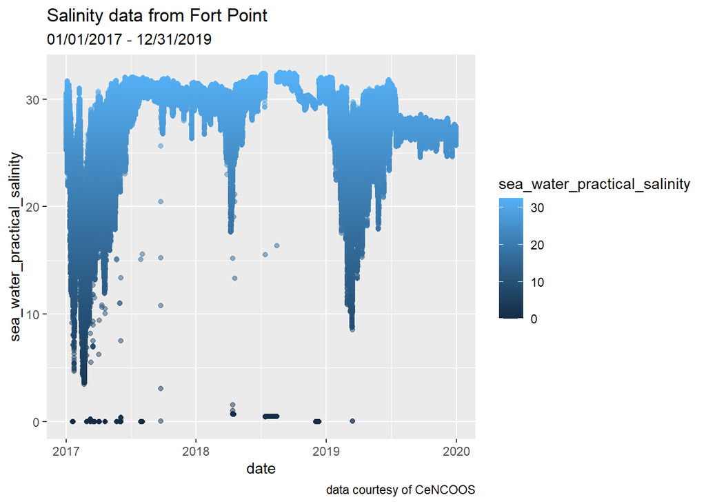

```r
fp%>%
  ggplot(aes(x=date, y=sea_water_practical_salinity, color=sea_water_practical_salinity))+
  geom_point(alpha=0.5)+
  labs(title="Salinity data from Fort Point",
       subtitle="01/01/2017 - 12/31/2019",
       caption= "data courtesy of CeNCOOS")
```

Roll apply using custom stat function. Again, width will depend on the frequencey of the time series. Data collected every 6 min so width=1680 is 7 days, 3360 is 14 days, 7200 is 30 days. 240 observations per day. Since 30 days worked for eos data I’m going to the same here so that it’s constent.

```r
s_data_rollstats<-fp%>%
  tq_mutate(
    select= sea_water_practical_salinity,
    mutate_fun= rollapply,
    width= 7200,
    align= "right",
    by.column= FALSE,
    FUN= custom_stat_fun_2,
    na.rm= TRUE)
```

Looks like it worked. Let’s filter and graph

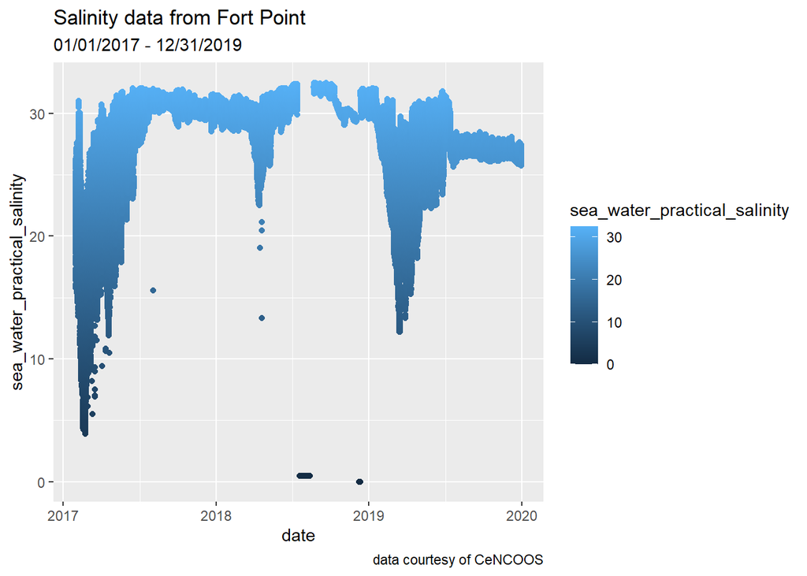

```r
clean_data<-filter(s_data_rollstats, sea_water_practical_salinity <hi.95 & sea_water_practical_salinity >lo.95)

fp_graph<- ggplot(data = clean_data, mapping = aes(x = date, y = sea_water_practical_salinity, color=sea_water_practical_salinity)) + geom_point()+
  labs(title="Salinity data from Fort Point",
       subtitle="01/01/2017 - 12/31/2019",
       caption= "data courtesy of CeNCOOS")

ggplot(data = clean_data, mapping = aes(x = date, y = sea_water_practical_salinity, color=sea_water_practical_salinity)) + geom_point()+
  labs(title="Salinity data from Fort Point",
       subtitle="01/01/2017 - 12/31/2019",
       caption= "data courtesy of CeNCOOS")
```

Looks like some outliers still remain. This data set has a “flag” column and it looks like they flagged most of the “0” salinity values. I’m going to remove those first and then contiue with the same method as above. Maybe this is the first step I should do to all my environmental data?

Remove salinity points where sea_water_practical_salinity_qc_tests = 4 which indicates FAIL.

From ERDDAP:  
sea_water_practical_salinity_qc_agg { Int32 _ChunkSizes 2045, 1; Int32 _FillValue 2; String _Unsigned “true”; Int32 actual_range 1, 4; String flag_meanings “PASS NOT_EVALUATED SUSPECT FAIL MISSING”; Int32 flag_values 1, 2, 3, 4, 9; String ioos_category “Other”; String long_name “Salinity QARTOD Aggregate Quality Flag”; Int32 missing_value 2; String standard_name “aggregate_quality_flag”; }

```r
fp<-filter(fp, sea_water_practical_salinity_qc_agg!=4)
```

Plot data with flagged salinity data removed Plot raw data

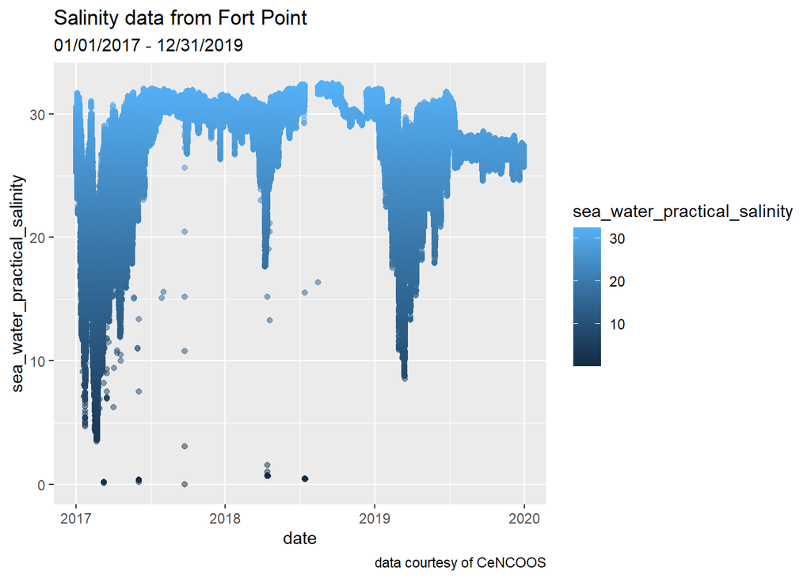

```r
fp%>%
  ggplot(aes(x=date, y=sea_water_practical_salinity, color=sea_water_practical_salinity))+
  geom_point(alpha=0.5)+
  labs(title="Salinity data from Fort Point",
       subtitle="01/01/2017 - 12/31/2019",
       caption= "data courtesy of CeNCOOS")
```

Roll apply using custom stat function

```r
s_data_rollstats<-fp%>%
  tq_mutate(
    select= sea_water_practical_salinity,
    mutate_fun= rollapply,
    width= 7200,
    align= "right",
    by.column= FALSE,
    FUN= custom_stat_fun_2,
    na.rm= TRUE)
```

Let’s filter and graph

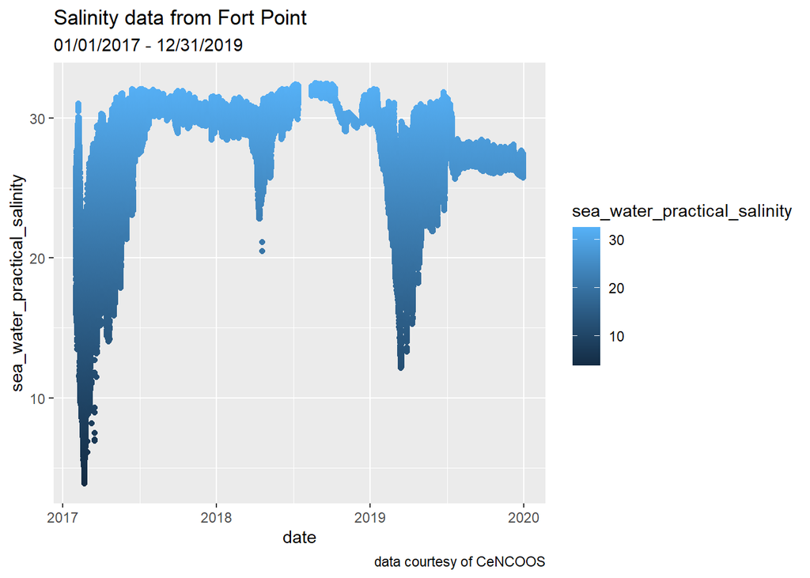

```r
clean_data<-filter(s_data_rollstats, sea_water_practical_salinity <hi.95 & sea_water_practical_salinity >lo.95)

fp_graph<- ggplot(data = clean_data, mapping = aes(x = date, y = sea_water_practical_salinity, color=sea_water_practical_salinity)) + geom_point()+
  labs(title="Salinity data from Fort Point",
       subtitle="01/01/2017 - 12/31/2019",
       caption= "data courtesy of CeNCOOS")

ggplot(data = clean_data, mapping = aes(x = date, y = sea_water_practical_salinity, color=sea_water_practical_salinity)) + geom_point()+
  labs(title="Salinity data from Fort Point",
       subtitle="01/01/2017 - 12/31/2019",
       caption= "data courtesy of CeNCOOS")
```

Looks much better. Not sure about those two points in 2018 <22.

*All together*

Now that I have all my graphs, I’m going to stack them

```r
ggarrange(cc_graph, eos_graph,rb_graph,fp_graph,  ncol= 1, nrow = 4)
```

[figure not shown]